# Project2

This is role playing. I am your new boss. I am in charge of production at ABC Beverage and you are a team of data scientists reporting to me. My leadership has told me that new regulations are requiring us to understand our manufacturing process, the predictive factors and be able to report to them our predictive model of PH.

Please use the historical data set I am providing. Build and report the factors in BOTH a technical and non-technical report. I like to use Word and Excel. Please provide your non-technical report in a business friendly readable document and your predictions in an Excel readable format. The technical report should show clearly the models you tested and how you selected your final approach.

Please submit both Rpubs links and .rmd files or other readable formats for technical and non-technical reports. Also submit the excel file showing the prediction of your models for pH.

## Data Exploration

```r
training<-read_xlsx("StudentData.xlsx")

testing<-read_xlsx("StudentEvaluation.xlsx") %>%
  mutate(PH = as.numeric(PH))
```

An initial glance at this dataset shows that our training set consists of a dimension of 2571 x 33 (rows x columns). Most of the features within this dataset are of a numeric nature with just 1 feature `Brand Code` being a categorical variable.

```r
skim(training)
```

Data summary

| Name | training |
| --- | --- |
| Number of rows | 2571 |
| Number of columns | 33 |
| _______________________ |  |
| Column type frequency: |  |
| character | 1 |
| numeric | 32 |
| ________________________ |  |
| Group variables | None |

**Variable type: character**

| skim_variable | n_missing | complete_rate | min | max | empty | n_unique | whitespace |
| --- | --- | --- | --- | --- | --- | --- | --- |
| Brand Code | 120 | 0.95 | 1 | 1 | 0 | 4 | 0 |

**Variable type: numeric**

| skim_variable | n_missing | complete_rate | mean | sd | p0 | p25 | p50 | p75 | p100 | hist |
| --- | --- | --- | --- | --- | --- | --- | --- | --- | --- | --- |
| Carb Volume | 10 | 1.00 | 5.37 | 0.11 | 5.04 | 5.29 | 5.35 | 5.45 | 5.70 | ▁▆▇▅▁ |
| Fill Ounces | 38 | 0.99 | 23.97 | 0.09 | 23.63 | 23.92 | 23.97 | 24.03 | 24.32 | ▁▂▇▂▁ |
| PC Volume | 39 | 0.98 | 0.28 | 0.06 | 0.08 | 0.24 | 0.27 | 0.31 | 0.48 | ▁▃▇▂▁ |
| Carb Pressure | 27 | 0.99 | 68.19 | 3.54 | 57.00 | 65.60 | 68.20 | 70.60 | 79.40 | ▁▅▇▃▁ |
| Carb Temp | 26 | 0.99 | 141.09 | 4.04 | 128.60 | 138.40 | 140.80 | 143.80 | 154.00 | ▁▅▇▃▁ |
| PSC | 33 | 0.99 | 0.08 | 0.05 | 0.00 | 0.05 | 0.08 | 0.11 | 0.27 | ▆▇▃▁▁ |
| PSC Fill | 23 | 0.99 | 0.20 | 0.12 | 0.00 | 0.10 | 0.18 | 0.26 | 0.62 | ▆▇▃▁▁ |
| PSC CO2 | 39 | 0.98 | 0.06 | 0.04 | 0.00 | 0.02 | 0.04 | 0.08 | 0.24 | ▇▅▂▁▁ |
| Mnf Flow | 2 | 1.00 | 24.57 | 119.48 | -100.20 | -100.00 | 65.20 | 140.80 | 229.40 | ▇▁▁▇▂ |
| Carb Pressure1 | 32 | 0.99 | 122.59 | 4.74 | 105.60 | 119.00 | 123.20 | 125.40 | 140.20 | ▁▃▇▂▁ |
| Fill Pressure | 22 | 0.99 | 47.92 | 3.18 | 34.60 | 46.00 | 46.40 | 50.00 | 60.40 | ▁▁▇▂▁ |
| Hyd Pressure1 | 11 | 1.00 | 12.44 | 12.43 | -0.80 | 0.00 | 11.40 | 20.20 | 58.00 | ▇▅▂▁▁ |
| Hyd Pressure2 | 15 | 0.99 | 20.96 | 16.39 | 0.00 | 0.00 | 28.60 | 34.60 | 59.40 | ▇▂▇▅▁ |
| Hyd Pressure3 | 15 | 0.99 | 20.46 | 15.98 | -1.20 | 0.00 | 27.60 | 33.40 | 50.00 | ▇▁▃▇▁ |
| Hyd Pressure4 | 30 | 0.99 | 96.29 | 13.12 | 52.00 | 86.00 | 96.00 | 102.00 | 142.00 | ▁▃▇▂▁ |
| Filler Level | 20 | 0.99 | 109.25 | 15.70 | 55.80 | 98.30 | 118.40 | 120.00 | 161.20 | ▁▃▅▇▁ |
| Filler Speed | 57 | 0.98 | 3687.20 | 770.82 | 998.00 | 3888.00 | 3982.00 | 3998.00 | 4030.00 | ▁▁▁▁▇ |
| Temperature | 14 | 0.99 | 65.97 | 1.38 | 63.60 | 65.20 | 65.60 | 66.40 | 76.20 | ▇▃▁▁▁ |
| Usage cont | 5 | 1.00 | 20.99 | 2.98 | 12.08 | 18.36 | 21.79 | 23.75 | 25.90 | ▁▃▅▃▇ |
| Carb Flow | 2 | 1.00 | 2468.35 | 1073.70 | 26.00 | 1144.00 | 3028.00 | 3186.00 | 5104.00 | ▂▅▆▇▁ |
| Density | 1 | 1.00 | 1.17 | 0.38 | 0.24 | 0.90 | 0.98 | 1.62 | 1.92 | ▁▅▇▂▆ |
| MFR | 212 | 0.92 | 704.05 | 73.90 | 31.40 | 706.30 | 724.00 | 731.00 | 868.60 | ▁▁▁▂▇ |
| Balling | 1 | 1.00 | 2.20 | 0.93 | -0.17 | 1.50 | 1.65 | 3.29 | 4.01 | ▁▇▇▁▇ |
| Pressure Vacuum | 0 | 1.00 | -5.22 | 0.57 | -6.60 | -5.60 | -5.40 | -5.00 | -3.60 | ▂▇▆▂▁ |
| PH | 4 | 1.00 | 8.55 | 0.17 | 7.88 | 8.44 | 8.54 | 8.68 | 9.36 | ▁▅▇▂▁ |
| Oxygen Filler | 12 | 1.00 | 0.05 | 0.05 | 0.00 | 0.02 | 0.03 | 0.06 | 0.40 | ▇▁▁▁▁ |
| Bowl Setpoint | 2 | 1.00 | 109.33 | 15.30 | 70.00 | 100.00 | 120.00 | 120.00 | 140.00 | ▁▂▃▇▁ |
| Pressure Setpoint | 12 | 1.00 | 47.62 | 2.04 | 44.00 | 46.00 | 46.00 | 50.00 | 52.00 | ▁▇▁▆▁ |
| Air Pressurer | 0 | 1.00 | 142.83 | 1.21 | 140.80 | 142.20 | 142.60 | 143.00 | 148.20 | ▅▇▁▁▁ |
| Alch Rel | 9 | 1.00 | 6.90 | 0.51 | 5.28 | 6.54 | 6.56 | 7.24 | 8.62 | ▁▇▂▃▁ |
| Carb Rel | 10 | 1.00 | 5.44 | 0.13 | 4.96 | 5.34 | 5.40 | 5.54 | 6.06 | ▁▇▇▂▁ |
| Balling Lvl | 1 | 1.00 | 2.05 | 0.87 | 0.00 | 1.38 | 1.48 | 3.14 | 3.66 | ▁▇▂▁▆ |

The figure below shows the distribution of the brand codes associated with the dataset, where we observe many a skewness towards brand `B` and a few unknown data points.

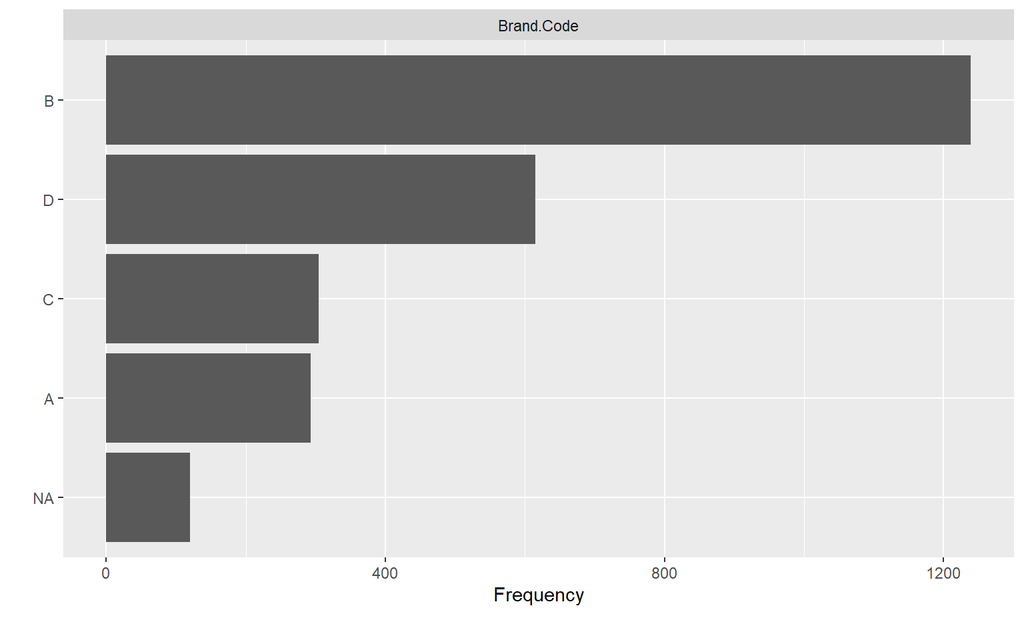

```r
plot_bar(training)
```

In terms of numeric data, we can plot the histogram below with the `DataExplorer` package and assess the distributions of all of our features including pH. The distribution of these features do differ. pH follows a gaussian distribution which is beneficial for predictions. Many features have slight skewness or bimodal gaussian distributions. We will handle these features via boxcox transformations.

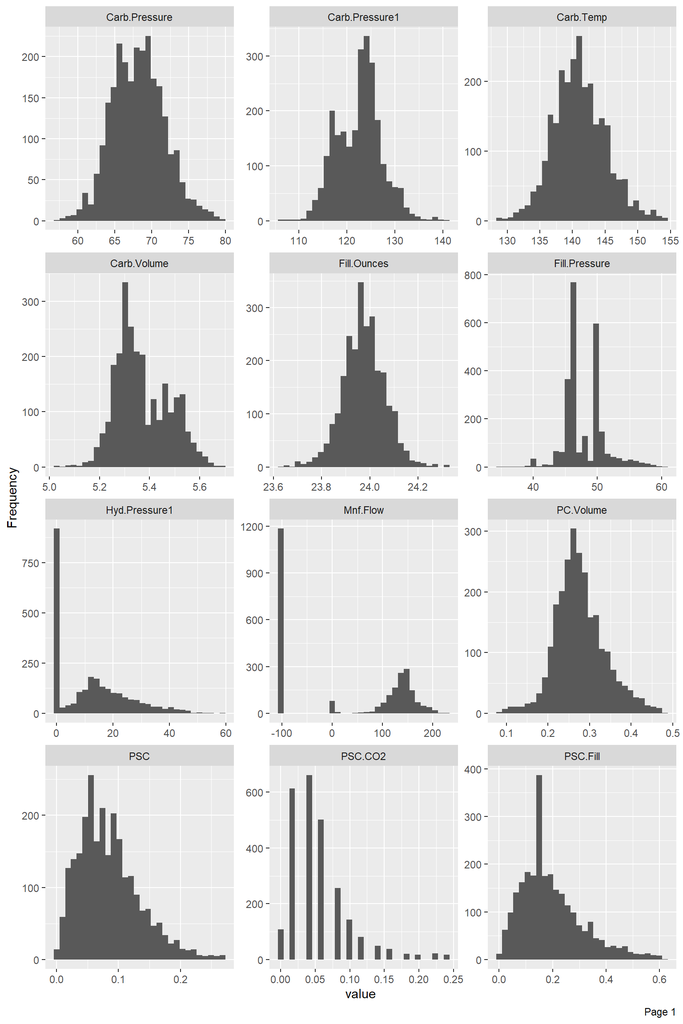

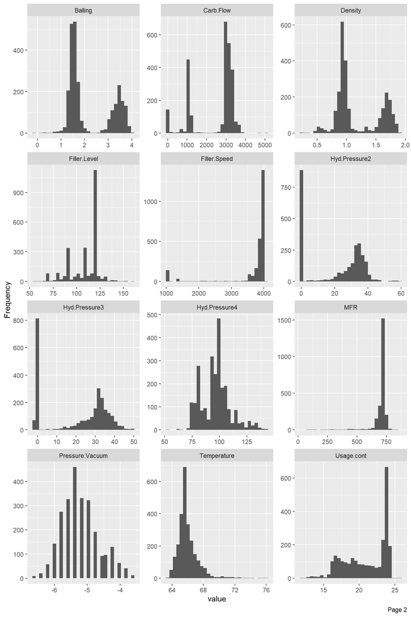

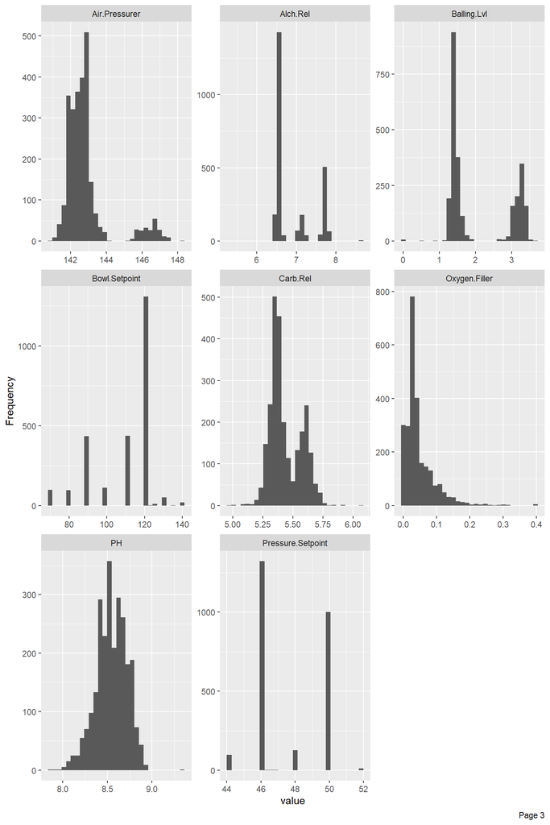

```r
plot_histogram(training,ncol  = 3)
```

Additionally, we want to look at multicolinearity associated with the dataset. because the number of columns is quite large, we will only produce a scatter matrix using features with the highest pearson (linear) correlations. These relationships,you can see there are some strong relationships such as between filler speed vs MFR, and Balling vs Balling level, these features will need to be assessed and potentially aggregated or removed to mitigate noise in the dataset.

```r
trainingnumeric<-training %>%
  select(-`Brand Code`)

ADHD_cors<-
  bind_rows(
    #pearson correlation of numeric features
    trainingnumeric %>%
      cor(method = "pearson", use = "pairwise.complete.obs") %>% as.data.frame() %>%
      rownames_to_column(var = "x") %>%
      pivot_longer(cols = -x, names_to = "y", values_to = "correlation") %>%
      mutate(cor_type = "pearson"),
    #spearman (monotonic) correlations of numeric features
    trainingnumeric %>%
      cor(method = "spearman", use = "pairwise.complete.obs") %>% as.data.frame() %>%
      rownames_to_column(var = "x") %>%
      pivot_longer(cols = -x, names_to = "y", values_to = "correlation") %>%
      mutate(cor_type = "spearman")
  )

topcors<-ADHD_cors %>%
  filter(!(x ==y)) %>%
  filter(cor_type=="pearson") %>%
  #distinct(correlation,.keep_all = T) %>%
  arrange(-abs(correlation))%>% #top_n(10, correlation) %>%
  head(10)


topcorvars<-c(pull(topcors,x),pull(topcors,y)) %>% unique
```

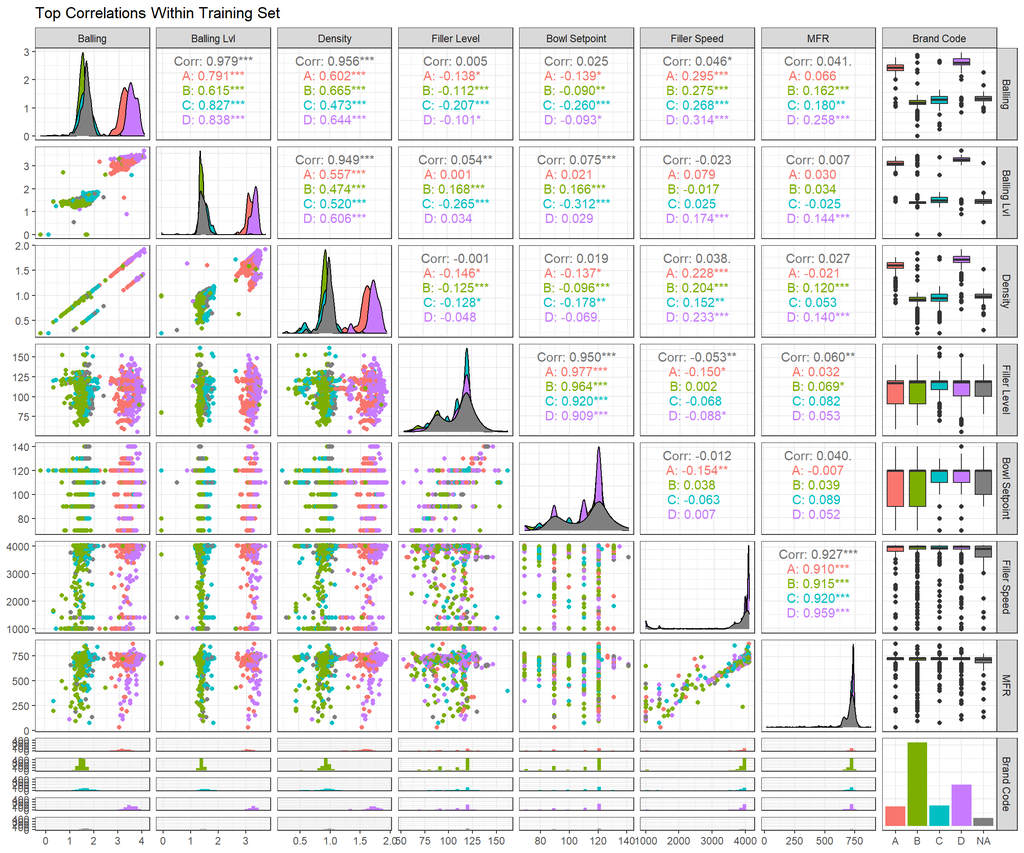

```r
topcorset<-training %>%
  select(all_of(c(topcorvars,'Brand Code')))
GGally::ggpairs(topcorset, progress = F, aes(color = `Brand Code`), title = "Top Correlations Within Training Set")+ theme_bw()
```

Since pH will be our main variable of interest, it is a good idea to observe any strong relationships between our predictor variables to pH, this time we will look at top spearman relationships to pH only. spearman provides a correlational strength of monotonicity which can capture both linear and non-linear relationships. We notice based on the figure below that most of the information seems a bit noisy, thus using a predictive machine learning model may provide value in identifying relationships.

```r
topcorsPH<-ADHD_cors %>%
  filter(!(x ==y)) %>%
  filter(cor_type=="spearman") %>%
  #distinct(correlation,.keep_all = T) %>%
  arrange(-abs(correlation))%>%
  filter(x == "PH" | y == "PH") %>%
  head(10)

topcorvarsPH<-c(pull(topcorsPH,x),pull(topcorsPH,y)) %>% unique
```

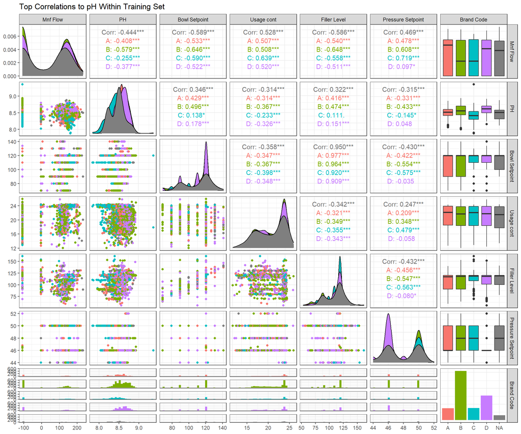

```r
topcorsetPH<-training %>%
  select(all_of(c(topcorvarsPH,'Brand Code')))
GGally::ggpairs(topcorsetPH, progress = F, aes(color = `Brand Code`), title = "Top Correlations to pH Within Training Set")+ theme_bw()
```

## Data Transformation

```r
datatrans<-training %>% recipe(~.) %>%
  step_mutate_at(contains(c("hyd pressure", "mnf flow","filler speed","carb flow", "balling")), fn = ~ifelse(.<0,NA,.)) %>%
  step_mutate_at(`Carb Volume`,`Filler Level`,PSC, `Air Pressurer`, `Bowl Setpoint`,`Oxygen Filler`,Temperature,MFR, fn = ~BoxCox(., lambda = BoxCox.lambda(.))) %>%
  step_mutate_at(`Brand Code`, fn = ~as.factor(.)) %>%
  step_impute_knn(all_predictors()) %>%
  step_rename(BrandCode=`Brand Code`) %>%
  step_dummy(all_nominal()) %>%
  step_corr(all_predictors(),threshold = 0.9) %>%
  step_nzv(all_predictors()) %>%
  prep()



training_cleaned<-
datatrans %>% bake(training)
```

For the Data preparation following baseline steps were made and the reasons are provided below

```r
datatrans$steps[[7]]$removals
```

```
[1] "Hyd Pressure3" "Balling"       "Bowl Setpoint" "Alch Rel"
[5] "Balling Lvl"
```

- **Removed low-variance features**: Removing any extremely low-variance data that will not provide useful data to the model and will only contribute to noise. At first glance, From `Data Exploration` section there doesnt appear to be any clear indicators of a low-variance variable with majority of categories recorded at a particular value. This is confirmed statistically with `tidymodels` where no features were removed due to low variance as shown below

```r
datatrans$steps[[8]]$removals
```

```
character(0)
```